# Transformations Solutions

## Question 1A (6 points)

Consider a discrete random variable $X$ with the following PMF:

$$P_X(x) =
\begin{cases}
0.2 &\text{for } x = -1 \\
0.5 &\text{for } x = 0 \\
0.3 &\text{for } x = 1 \\
0 &\text{otherwise}
\end{cases}$$

We would like to find the PMF of the transformed random variable $Y = g(X) = 2X$. Fill in letters a-f with the numbers that would complete the PMF for $Y$ found below:

$$P_Y(y) =
\begin{cases}
0.2 &\text{for } y = -2 \\
0.5 &\text{for } y = 0 \\
0.3 &\text{for } y = 2 \\
0 &\text{otherwise}
\end{cases}$$

## Question 1B (2 points)

```r
rPX_31 <- function(n){
  sample(c(-1, 0, 1), n, TRUE, prob = c(0.2, 0.5, 0.3))
}
```

The function `rPX_31` above takes as input a positive integer `n` and returns $n$ random samples of the random variable $X$. Use this function to produce $n = 10000$ random draws of $X$ and then use these draws to obtain draws of $Y$ where $Y = g(X) = 2X$. Then use these samples to compute an estimate of $P(Y = y)$ for each value of $y$.

```r
x <- rPX_31(10000)
y <- 2*x

table(y)/length(y)
```

```
y
    -2      0      2
0.1988 0.4970 0.3042
```

## Question 2 (5 points)

Consider the same discrete random variable presented in Question 1. Fill in the missing letters a-e with the numbers needed to complete the function for the CDF of $Y$ found below:

$$F_Y(y) =
\begin{cases}
0 &\text{for } y < -2 \\
0.2 &\text{for } -2 \leq y < 0 \\
0.7 &\text{for } 0 \leq y < 2 \\
1 &\text{for } y \geq 2
\end{cases}$$

## Question 3A (5 points)

Consider a continuous random variable $X$ with PDF:

$$f_X(x) =
\begin{cases}
\frac{3}{14}(x^2 + 1) &\text{for } x \in (0, 2) \\
0 &\text{otherwise}
\end{cases}$$

We would like to find the PDF of the transformation $Y = g(X) = \sqrt{X}$. Fill in the letters a-e below with the numbers needed to complete the formula for the PDF of $Y$.

$$f_Y(y) =
\begin{cases}
\frac{6}{14}y(y^4+1) &\text{for } y \in (0, \sqrt{2}) \\
0 &\text{otherwise}
\end{cases}$$

## Question 3B (2 points)

```r
rfX_33 <- function(n){
  u_samps <- runif(n)

  f_obj <- function(u){
    f_inner <- function(x){
      3/14*(1/3*x^3 + x) - u
    }
  }

  sapply(u_samps, function(u){
    f_obj_u <- f_obj(u)
    uniroot(f_obj_u, c(0, 2), tol = 10e-10)$root
  })
}
```

The function `rfX_33` above takes as input an integer `n` and return $n$ random draws of the random variable with the PDF given in Question 3A. Use this function produce $n = 10000$ random draws of $X$ and then use these draws to obtain draws of $Y$ where $Y = g(X) = \sqrt{X}$. Create a histogram of the draws of $Y$.

You may use the ggplot2 package or you can use the built-in function `hist` to create the histogram. When using `hist`, you simply need to input the variable (e.g., `hist(Y)`).

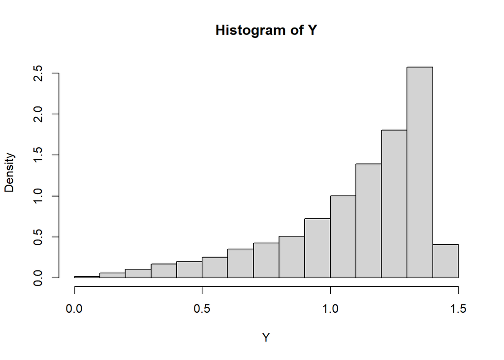

```r
x <- rfX_33(10000)
y <- sqrt(x)

hist(y, main = "Histogram of Y", xlab = "Y", freq = FALSE)
```

## Question 4 (4 points)

Consider the same continuous random variable presented in Question 3A. Fill in the missing letters a-d with the numbers needed to complete the function for the CDF of $Y$ found below:

$$F_Y(y) =
\begin{cases}
0 &\text{for } y < 0 \\
\frac{1}{14}y^6 + \frac{3}{14}y^2 &\text{for } 0 \leq y < \sqrt{2} \\
1 &\text{for } y \geq \sqrt{2}
\end{cases}$$